# 데이터 가져오기 - GitHub

텍스트 RSS 피드

xwMOOC

2019-05-27

# 1 텍스트 RSS

RSS는 원래 RDF Site Summary에서 출발하여 Rich Site Summary, Really Simple Syndication으로 알려진 웹 사용자 혹은 응용프로그램이 온라인 콘텐츠를 가져오게 된 표준규약으로 “자연어 처리”의 중요한 말뭉치(Corpus)의 한 축을 담당하고 있다.

- [유명한 RSS 피드 모음](https://raw.githubusercontent.com/DataWookie/feedeR/master/tests/testthat/test-feeds.txt)

RSS를 R에서 가져오는데 [tidyRSS](https://github.com/RobertMyles/tidyrss) 팩키지가 개발되어 수월하게 텍스트 데이터를 가져올 수 있다. RSS 텍스트 데이터를 처리하는 기본 작업 흐름은 다음과 같다. 과거 별도 RSS 팩키지를 사용해야 했지만, `tidyRSS`가 RSS, Atom, JSON, geoRSS 피드도 받아내는 기능이 있어 feedeR 팩키지를 참조해도 좋을 듯 싶다.

[figure not shown]

RSS 데이터 작업흐름도

```r
knitr::include_graphics("fig/rss_pkg.png")
```

# 2 `tidyRSS` 헬로월드

https://statmodeling.stat.columbia.edu/ 웹사이트의 블로그 RSS 피드를 `tidyRSS` 팩키지 `tidyfeed()` 함수를 사용해서 블로그 텍스트를 가져온다. 가져온 데이터를 `tidytext` 자연어 처리 흐름에 맞춰 데이터프레임으로 정제하고 `ggplot`으로 시각화한다.

```r
library(tidyRSS)
library(tidytext)
library(tidyverse)

## RSS 블로그 데이터 가져오기
rss <- tidyfeed("https://statmodeling.stat.columbia.edu/feed/")

DT::datatable(rss)
```

|  | feed_title | feed_link | feed_description | feed_last_updated | feed_language | feed_update_period | item_title | item_creator | item_date_published | item_description | item_link | item_categories |
| --- | --- | --- | --- | --- | --- | --- | --- | --- | --- | --- | --- | --- |
| 1 | Statistical Modeling, Causal Inference, and Social Science | https://statmodeling.stat.columbia.edu |  | 2019-05-26T21:19:45Z | en-US | hourly | I have zero problem with people reporting results they found with p=0.1. Or p=0.2. Whatever. The problem is with the attitude that publication should imply some sort of certainty. | Andrew | 2019-05-26T21:19:45Z |  | https://statmodeling.stat.columbia.edu/2019/05/26/i-have-zero-problem-with-people-reporting-results-they-found-with-p0-1-or-p0-2-whatever-the-problem-is-with-the-attitude-that-publication-should-imply… | Zombies |
| 2 | Statistical Modeling, Causal Inference, and Social Science | https://statmodeling.stat.columbia.edu |  | 2019-05-26T21:19:45Z | en-US | hourly | Crystallography Corner: The result is difficult to reproduce, but the result is still valid. | Andrew | 2019-05-26T13:09:37Z | Joel Bernstein writes: I just finished reading your oped article on reproducibility in science. As an experimental scientist &amp;#8211; more precisely a chemical crystallographer &amp;#8211; I have h… | https://statmodeling.stat.columbia.edu/2019/05/26/crystallography-corner-the-result-is-difficult-to-reproduce-but-the-result-is-still-valid/ | Miscellaneous Science |
| 3 | Statistical Modeling, Causal Inference, and Social Science | https://statmodeling.stat.columbia.edu |  | 2019-05-26T21:19:45Z | en-US | hourly | Donald J. Trump and Robert E. Lee | Andrew | 2019-05-25T13:24:40Z | The other day the president made some news by praising Civil War general Robert E. Lee, and it struck me that Trump and Lee had a certain amount in common. Not in their personalities, but in their sit… | https://statmodeling.stat.columbia.edu/2019/05/25/donald-j-trump-and-robert-e-lee/ | Political Science |
| 4 | Statistical Modeling, Causal Inference, and Social Science | https://statmodeling.stat.columbia.edu |  | 2019-05-26T21:19:45Z | en-US | hourly | Against Arianism 3: Consider the cognitive models of the field | Dan Simpson | 2019-05-24T19:28:30Z | &amp;#8220;You took my sadness out of context at the Mariners Apartment Complex&amp;#8221; – Lana Del Rey It&amp;#8217;s sunny, I&amp;#8217;m in England, and I&amp;#8217;m having a very tasty beer, an… | https://statmodeling.stat.columbia.edu/2019/05/24/against-arianism-3-consider-the-cognitive-models-of-the-field/ | Uncategorized |
| 5 | Statistical Modeling, Causal Inference, and Social Science | https://statmodeling.stat.columbia.edu |  | 2019-05-26T21:19:45Z | en-US | hourly | John Le Carre is good at integrating thought and action | Andrew | 2019-05-24T13:49:51Z | I was reading a couple old Le Carre spy novels. They have their strong points and their weak points; I&amp;#8217;m not gonna claim that Le Carre is a great writer. He&amp;#8217;s no George Orwell or G… | https://statmodeling.stat.columbia.edu/2019/05/24/john-le-carre-is-good-at-integrating-thought-and-action/ | ['Literature', 'Teaching'] |
| 6 | Statistical Modeling, Causal Inference, and Social Science | https://statmodeling.stat.columbia.edu |  | 2019-05-26T21:19:45Z | en-US | hourly | Pushing the guy in front of the trolley | Andrew | 2019-05-23T13:00:54Z | So. I was reading the London Review of Books the other day and came across this passage by the philosopher Kieran Setiya: Some of the most striking discoveries of experimental philosophers concern the… | https://statmodeling.stat.columbia.edu/2019/05/23/41068/ | Miscellaneous Science |
| 7 | Statistical Modeling, Causal Inference, and Social Science | https://statmodeling.stat.columbia.edu |  | 2019-05-26T21:19:45Z | en-US | hourly | Going beyond the rainbow color scheme for statistical graphics | Andrew | 2019-05-22T17:12:52Z | Yesterday in our discussion of easy ways to improve your graphs, a commenter wrote: I recently read and enjoyed several articles about alternatives to the rainbow color palette. I particularly like th… | https://statmodeling.stat.columbia.edu/2019/05/22/going-beyond-the-rainbow-color-scheme-for-statistical-graphics/ | ['Statistical graphics', 'Zombies'] |
| 8 | Statistical Modeling, Causal Inference, and Social Science | https://statmodeling.stat.columbia.edu |  | 2019-05-26T21:19:45Z | en-US | hourly | (from Yair): What Happened in the 2018 Election | Andrew | 2019-05-22T13:43:14Z | Yair writes: Immediately following the 2018 election, we published an analysis of demographic voting patterns, showing our best estimates of what happened in the election and putting it into context c… | https://statmodeling.stat.columbia.edu/2019/05/22/from-yair-what-happened-in-the-2018-election/ | Political Science |
| 9 | Statistical Modeling, Causal Inference, and Social Science | https://statmodeling.stat.columbia.edu |  | 2019-05-26T21:19:45Z | en-US | hourly | What are some common but easily avoidable graphical mistakes? | Andrew | 2019-05-21T20:49:06Z | John Kastellec writes: I was thinking about writing a short paper aimed at getting political scientists to not make some common but easily avoidable graphical mistakes. I’ve come up with the following… | https://statmodeling.stat.columbia.edu/2019/05/21/what-are-some-common-but-easily-avoidable-graphical-mistakes/ | ['Political Science', 'Statistical graphics'] |
| 10 | Statistical Modeling, Causal Inference, and Social Science | https://statmodeling.stat.columbia.edu |  | 2019-05-26T21:19:45Z | en-US | hourly | Neural nets vs. regression models | Andrew | 2019-05-21T13:55:46Z | Eliot Johnson writes: I have a question concerning papers comparing two broad domains of modeling: neural nets and statistical models. Both terms are catch-alls, within each of which there are, quite … | https://statmodeling.stat.columbia.edu/2019/05/21/neural-nets-vs-statistical-models/ | ['Bayesian Statistics', 'Miscellaneous Statistics', 'Statistical computing'] |

[output cut: 40 more lines]

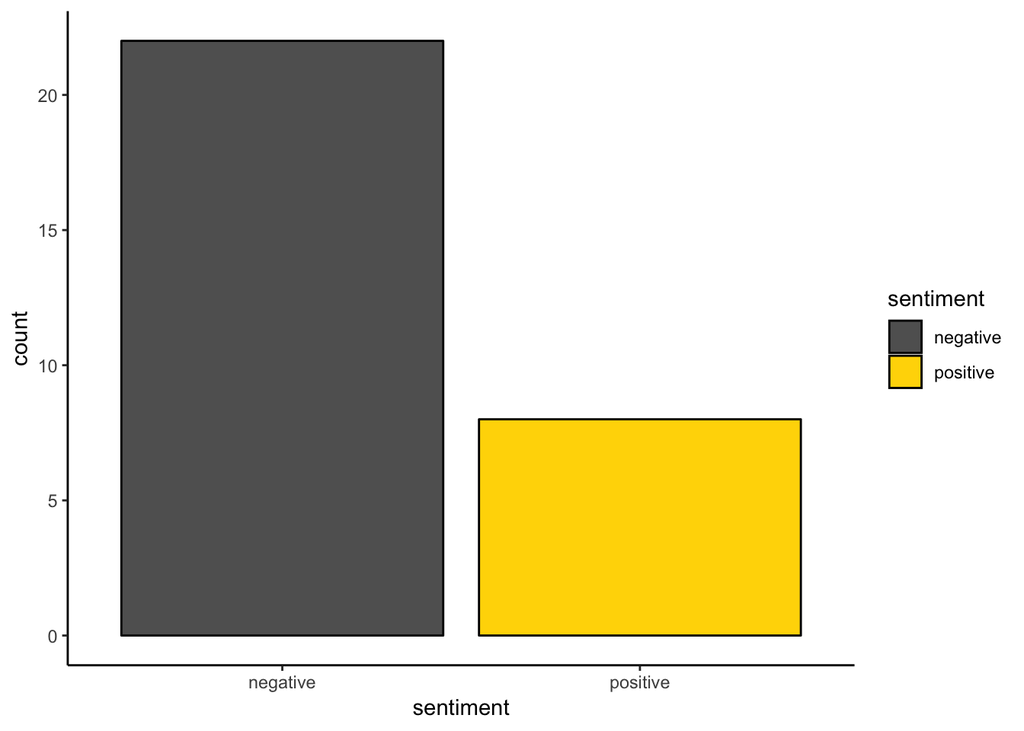

```r
## 텍스트 데이터 전처리
rss_t <- rss %>%
  unnest_tokens(word, item_title) %>%
  anti_join(stop_words) %>%
  inner_join(get_sentiments("bing"), by = "word") %>%
  mutate(week = lubridate::week(item_date_published))

## 감성분석 시각화
ggplot(rss_t, aes(x = sentiment)) +
  geom_bar(aes(fill = sentiment), colour = "black") +
  theme_classic() +
  scale_fill_manual(values = c("#616161", "#FFD700"))
```

# 3 한글 RSS

[국내 48곳 언론사/포탈 뉴스 RSS 모음](http://w3devlabs.net/wp/?p=52)을 통해서 주요 언론사 뉴스 RSS를 받아볼 수 있다.

**`xmlXPathEval: evaluation failed`** 오류 발생시 [Install libxml2 on Mac OSX](http://macappstore.org/libxml2/)을 참조하여 `libxml2`를 설치하여 해결한다.

```r
> hani_rss <- tidyfeed("http://www.hani.co.kr/rss/")
xmlXPathEval: evaluation failed
```

```r
joins_rss <- tidyRSS::tidyfeed("http://rss.joinsmsn.com/joins_news_list.xml")
```

[output not shown]